# An Analysis of Customer Activity for Cyclistic Bike-Share

## Overview

Here at Cyclistic, we have developed a network of bikes in the city of Chicago, allowing our customers to bike around the city. Our current business model includes two types of customers - those who purchase ride passes, who are considered “casual riders”, and those who purchase annual bike share memberships. Recently, our financial analysis determined that customers who purchase memberships are more profitable than casual riders. The marketing analytics team conducted an analysis of the riding habits of casual riders and membership riders. Based on those results, we believe that it would be beneficial to adjust our marketing strategy to convert our casual riders into membership riders.

## Data

The data used in this analysis comes from Cyclistic’s historical database. We retrieved the ride dataset from the last twelve months (July 2020 to June 2021) and compiled it into a single dataset for analysis. No observations included personal or sensitive information, and could instead be identified by anonymized ride IDs. This dataset included data such as when a ride started and if the rider was a casual rider or a membership rider. For the purpose of our analysis, we then added additional columns, allowing us to see the travel time, season, day of the week, and time of day of a ride. The following is a glimpse into the structure of the final dataset.

We then proceeded to clean our aggregated dataset to improve the quality of our data, and thus our analysis. We first removed any observations that had a negative travel time. We calculated the travel time by determining the difference between the recorded start time and end time. A negative result shows that the recorded end time is before the start time, which is impossible. As such, those data points were thrown out.

The next step in our cleaning was to scan and remove any data points that didn’t have a unique ride ID. By definition, each ride ID should be unique. Therefore, any observations that had an identical ID to another would either be a duplicate of another observation, or have an error. Regardless, those data points are undesirable.

Then, we removed any observations that exceeded 24 hours. We reasoned that since these observations comprised a negligible portion of the whole dataset, and since the sheer length of the rides makes it difficult to draw conclusions from these particular points, it would be beneficial to the analysis to simply remove them from consideration.

Finally, we decided to remove any observations that were missing data. While these incomplete observations may not have necessarily had an impact on our analysis, no column in the dataset allowed for null values. As such, the integrity of observations that included null values could be called into question. So it was safer to remove them.

```r
glimpse(agg_bikes)
```

```
## Rows: 4,399,563
## Columns: 17
## $ ride_id            <chr> "762198876D69004D", "BEC9C9FBA0D4CF1B", "D2FD8EA432~
## $ rideable_type      <chr> "docked_bike", "docked_bike", "docked_bike", "docke~
## $ started_at         <dttm> 2020-07-09 15:22:02, 2020-07-24 23:56:30, 2020-07-~
## $ ended_at           <dttm> 2020-07-09 15:25:52, 2020-07-25 00:20:17, 2020-07-~
## $ start_station_name <chr> "Ritchie Ct & Banks St", "Halsted St & Roscoe St", ~
## $ start_station_id   <chr> "180", "299", "329", "181", "268", "635", "113", "2~
## $ end_station_name   <chr> "Wells St & Evergreen Ave", "Broadway & Ridge Ave",~
## $ end_station_id     <chr> "291", "461", "156", "94", "301", "289", "140", "31~
## $ start_lat          <dbl> 41.90687, 41.94367, 41.93259, 41.89076, 41.91172, 4~
## $ start_lng          <dbl> -87.62622, -87.64895, -87.63643, -87.63170, -87.626~
## $ end_lat            <dbl> 41.90672, 41.98404, 41.93650, 41.91831, 41.90799, 4~
## $ end_lng            <dbl> -87.63483, -87.66027, -87.64754, -87.63628, -87.631~
## $ member_casual      <chr> "member", "member", "casual", "casual", "member", "~
## $ ride_length        <dbl> 4, 24, 7, 21, 5, 16, 18, 9, 15, 10, 9, 19, 11, 6, 7~
## $ day_of_week        <fct> Thu, Fri, Wed, Fri, Sat, Tue, Thu, Mon, Thu, Mon, M~
## $ season             <fct> Summer, Summer, Summer, Summer, Summer, Summer, Sum~
## $ time_of_day        <fct> Afternoon, Evening, Evening, Evening, Morning, Afte~
```

```r
head(agg_bikes)
```

```
## # A tibble: 6 x 17
##   ride_id rideable_type started_at          ended_at            start_station_n~
##   <chr>   <chr>         <dttm>              <dttm>              <chr>
## 1 762198~ docked_bike   2020-07-09 15:22:02 2020-07-09 15:25:52 Ritchie Ct & Ba~
## 2 BEC9C9~ docked_bike   2020-07-24 23:56:30 2020-07-25 00:20:17 Halsted St & Ro~
## 3 D2FD8E~ docked_bike   2020-07-08 19:49:07 2020-07-08 19:56:22 Lake Shore Dr &~
## 4 54AE59~ docked_bike   2020-07-17 19:06:42 2020-07-17 19:27:38 LaSalle St & Il~
## 5 54025F~ docked_bike   2020-07-04 10:39:57 2020-07-04 10:45:05 Lake Shore Dr &~
## 6 65636B~ docked_bike   2020-07-28 16:33:03 2020-07-28 16:49:10 Fairbanks St & ~
## # ... with 12 more variables: start_station_id <chr>, end_station_name <chr>,
## #   end_station_id <chr>, start_lat <dbl>, start_lng <dbl>, end_lat <dbl>,
## #   end_lng <dbl>, member_casual <chr>, ride_length <dbl>, day_of_week <fct>,
## #   season <fct>, time_of_day <fct>
```

## Data Analysis - Casual Riders vs Membership Riders

Since we wanted to analyze the riding habits of casual riders and membership riders, then compare them, we started all of our analyses by grouping together all observations where the rider was a casual rider and all observations where the rider was a membership rider. In the following bar charts, casual riders are represented with the color red, and membership riders are represented with the color blue.

# Statistics

The first analysis we conducted was to compare the time taken between taking a bike and returning it to a docking station acros our two groups. This information is stored in a variable we labeled as ‘ride_length’. Compare the statistics of the casual riders…

```r
summ_casual
```

```
##   ride_length
##  Min.   :   1.00
##  1st Qu.:  11.00
##  Median :  19.00
##  Mean   :  33.44
##  3rd Qu.:  36.00
##  Max.   :1440.00
```

to the statistics of the membership riders…

```r
summ_member
```

```
##   ride_length
##  Min.   :   1.00
##  1st Qu.:   6.00
##  Median :  11.00
##  Mean   :  14.97
##  3rd Qu.:  19.00
##  Max.   :1440.00
```

Comparing the midpoint values of the two groups, it is clear that casual riders generally go on longer rides than membership riders. Across the mean and all three quartile measures, casual riders rode for roughly twice as long as membership riders.

# Day of the Week

We then decided to compare the number of rides based on the day of the week.

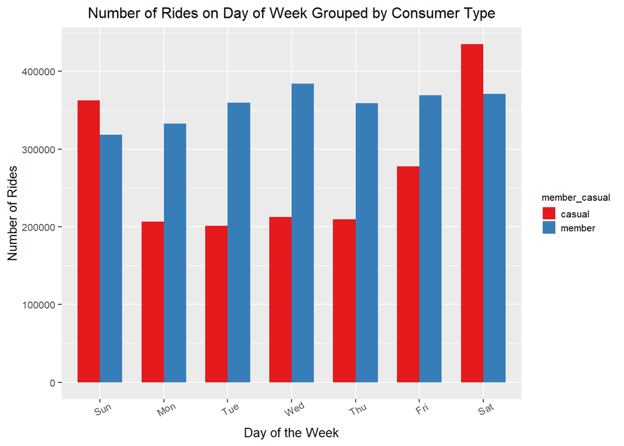

Note that membership ride numbers are consistent throughout the week, with a subtle peak on Wednesday, in the middle of the week. Now compare this constant trend to the data from casual riders. On weekdays, there are noticeably fewer casual rides compared to membership rides. But on the weekend, there are significantly more casual rides, even surpassing membership rides.

# Season

Now, let’s consider rider behavior by season. Seasons were measured by the solstices and equinoxes, rather than simply by month. For example, March 15th is considered winter, since it falls before the Spring Equinox on March 20th.

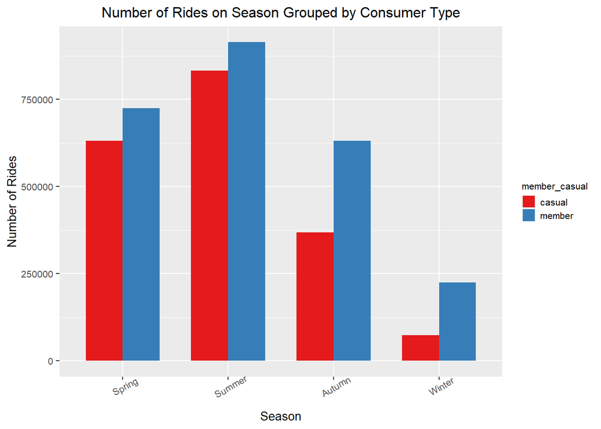

Across both groups, we can see that there are more rides during the warmer seasons compared to the colder seasons, which shouldn’t be particularly surprising. But, it is worth noting that there are more membership riders during the cold seasons than casual riders. This is especially true in the winter, where there are at least three times as many membership riders compared to casual riders.

# Time of Day

Finally, we decided to analyze the number of rides by the time of day. Time of day was divided into four categories- morning, afternoon, evening, and night. Morning went from 6 AM to noon, afternoon spanned until 6 PM, evening was before midnight, and night was from midnight to 6 AM.

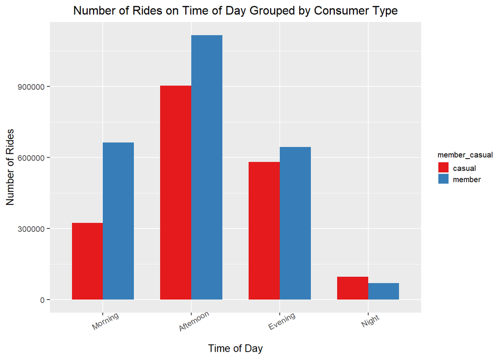

Of note here is that morning riders are more likely to be membership riders rather than casual riders. While there are more membership riders than casual riders in the afternoon and evening, this is in line with general trends and not great enough to give specific attention. Additionally, it is curious that there are more casual riders in the middle of the night, night riders make up so few points comparatively that this is not important to the overall comparison.

## Recommendations

From our data analysis, we were able to identify trends among casual riders, membership riders, and across both groups. With this new information, we can adjust our business model and marketing to convert casual riders into membership riders. Our approach will be focused on making Cyclistic memberships more appealing without diminishing the value of our ride passes. If, for example, we increase the cost of passes on weekends to make membership fees seem cheaper, we may simply lose customers rather than convert them.

Our suggested business decisions are based on the trends among riders and the differences we found between them. They also involve some of our own speculation as to why these trends and differences exist. With the data available to us, we were unable to determine underlying circumstances with more confidence, therefore we suggest that there should also be further research into rider habits and preferences.

# Business Discounts

The most notable difference we uncovered in our analysis was that casual riders are significantly more active on the weekends compared to during weekdays. We speculate that casual riders are more likely to use Cyclistic for weekend leisure travel. Membership riders are more likely to be people who use Cyclistic to commute to and from work during the week.

With this knowledge, we suggest that Cyclistic partner with common recreational spots to provide benefits for membership riders. For example, working with a local museum or a popular restaurant to give discounts to members. For casual riders, who likely visit these sorts of places on the weekend, these discounts could work as an extra incentive to convert to a Cyclistic membership. They would want to save money at other establishments, and become members to do so.

# Seasonal Benefits

Based our seasonal analysis, we can see that the majority of casual and membership riders alike ride more in the spring and summer. Creating benefits for members may encourage casual members to pay our annual fee for these benefits. In popular seasons, it would incentivize people who already enjoy biking at those times. During less popular seasons, the right benefits may encourage people to bike during those times as well.

With our current data, we cannot say which types of benefits may be most effective. Casual riders should be surveyed to determine which features they’d find most appealing. Some potential benefits may include exercise courses and path suggestions for people who take our bikes to exercise, or audio tracks about different parts of the city’s history and events for people who want to learn more about the places they bike through.

# Biking Club

In our analysis of trends for time of day, we found that casual bikers are most likely to ride in the afternoon and evening, while membership riders ride in the morning equally as frequently as in the evening. This data supports our previous theory that casual riders tend to bike for leisure and that membership riders tend to bike to commute. Annual members get up in the morning to go to work, and casual riders go out in the afternoon to enjoy their day.

We propose that Cyclistic should promote leisure biking with an afternoon and evening membership biking club for riders to meet and socialize with fellow members. Creating an exclusive club would be desirable for casual riders, especially those who prefer to relax with others or want to meet new people.

## Conclusion

Thank you for taking the time to read about our findings. Expanding our membership base is a crucial part of Cyclistic’s success, and we hope that you take our findings and recommendations into account when considering Cyclistic’s business plan moving forward. For any questions, please contact xxxxxxxxxxxxxxxxxxxx.